# Reference label transfer exploration for SCPCS000176

Maud PLASCHKA

2024-08-13

## Introduction

The aim is to find an appropriate reference to perform label transfer as a step of the annotation of the Wilms tumor dataset for the sample `param$sample_id` =

```r
params$sample_id
```

```
## [1] "SCPCS000176"
```

The use of the right reference is crucial. It is recommended that the cell types in the reference is representative to the cell types to be annotated in the query.

Wilms tumors can contain up to three histologies that resemble fetal kidney: blastema, stroma, and epithelia [1-2]. Because of their histological similarity to fetal kidneys, Wilms tumors are thought to arise from developmental derangements in embryonic renal progenitors.

### Human fetal kidney atlas Stewart et al.

We first wanted to try the human fetal kidney atlas to transfer label into the Wilms tumor samples using azimuth. You can find more about the human kidney atlas here: https://www.kidneycellatlas.org/ [3]

Using this reference, we test two workflows for label transfer:

- `Azimuth v5`,
- `Seurat v4` as described here https://satijalab.org/seurat/articles/integration_mapping.html#cell-type-classification-using-an-integrated-reference

### Azimuth Human fetal atlas Cao et al.

Azimuth also provide a human fetal atlas as a reference [4].

The data can be found on Zenodo: https://zenodo.org/records/4738021#.YJIW4C2ZNQI

The reference contain cells from 15 organs including kidney from fetal samples. Here we will use `Azimuth` to transfer labels from the reference.

### Packages

Load required packages in the following chunk, if needed. Do not install packages here; only load them with the `library()` function.

```r
library("Seurat")
library(sctransform)
library(SCpubr)
library(tidyverse)
library(patchwork)
library(SingleCellExperiment)

set.seed(params$seed)
```

### Base directories

```r
# The base path for the OpenScPCA repository, found by its (hidden) .git directory
repository_base <- rprojroot::find_root(rprojroot::is_git_root)

# The current data directory, found within the repository base directory
data_dir <- file.path(repository_base, "data", params$current, params$scpca_project_id)

# The path to this module
module_base <- file.path(repository_base, "analyses", "cell-type-wilms-tumor-06")
```

### Input files

#### Reference

rds data can be downloaded using the URL defined in `param$ref_url`.

Please note that this download link permanently references the current version of the dataset (08/2024). If this dataset is updated, a new download link will be created that permanently references the next version of this dataset.

We place it in the `scratch` folder of the module because it is a temporary file.

```r
path_to_reference <- file.path(module_base, "scratch", "fetal_full.rds")

download.file(params$ref_url, path_to_reference)
```

#### Query

In this notebook, we test the label transfer from the fetal kidney atlas (reference) to the Wilms tumor sample defined in `params$sample_id` from the Wilms tumor dataset `param$scpca_project_id`

```r
filelist <- list.files(data_dir, full.names = TRUE)

# select the 40 Wilms tumor single nucleus folders only
filedir <- filelist[grepl(params$sample_id, filelist)]
```

### Output file

Reports will be saved in the `notebook\00-reference` directory.

## Using the Human Kidney Atlas - Fetal as a reference

### Load and pre-process the query data

```r
file <- list.files(filedir)
file <- file[grepl("_processed.rds", file)]

# open the processed rds object
sce <- readRDS(paste0(filedir, "/", file))
```

```r
# convert to seurat
srat <- CreateSeuratObject(counts = counts(sce),
                                    assay = "RNA",
                                    project = params$sample_id
                           )

# convert colData and rowData to data.frame for use in the Seurat object
cell_metadata <- as.data.frame(colData(sce))
row_metadata <- as.data.frame(rowData(sce))

# add cell metadata (colData) from SingleCellExperiment to Seurat
srat@meta.data <- cell_metadata

# add row metadata (rowData) from SingleCellExperiment to Seurat
srat[["RNA"]]@meta.data <- row_metadata

# add metadata from SingleCellExperiment to Seurat
srat@misc <- metadata(sce)


# Normalization
options(future.globals.maxSize= 8912896000000)
srat <- SCTransform(srat, verbose = F, conserve.memory = TRUE)

# dimensionality reduction
srat <- RunPCA(srat, verbose = F)
srat <- RunUMAP(srat, dims = 1:50, verbose = F)

# clustering
srat    <- FindNeighbors(srat, dims = 1:50, verbose = F)
srat    <- FindClusters(srat, verbose = T)
```

```
## Modularity Optimizer version 1.3.0 by Ludo Waltman and Nees Jan van Eck
##
## Number of nodes: 1483
## Number of edges: 69118
##
## Running Louvain algorithm...
## Maximum modularity in 10 random starts: 0.7573
## Number of communities: 8
## Elapsed time: 0 seconds
```

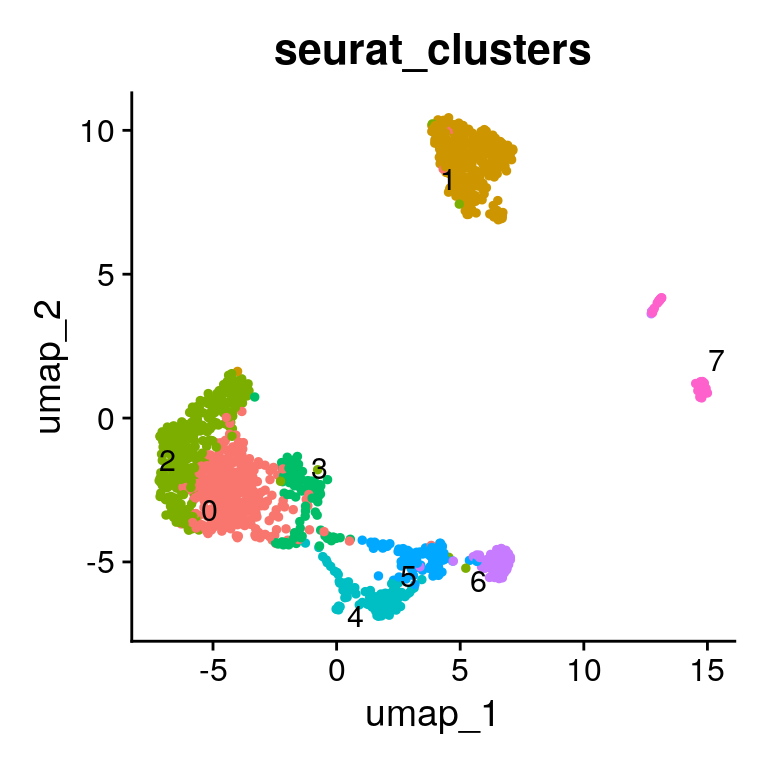

```r
DimPlot(srat, reduction = "umap", dims = c(1,2), group.by = "seurat_clusters", label = TRUE, repel = TRUE) + NoLegend()
```

### Load the reference

```r
seurat <- readRDS(path_to_reference)

options(future.globals.maxSize= 891289600000)
s <- SCTransform(seurat, verbose = FALSE, method = "glmGamPoi", conserve.memory = TRUE)
s <- RunPCA(s, npcs = 50, verbose = FALSE)
s <- RunUMAP(s, dims = 1:50, verbose = FALSE, return.model = TRUE)
```

[figure not shown]

```r
d2 <- do_DimPlot(s, reduction = "umap", dims = c(1,2), group.by = "compartment", label = TRUE, repel = TRUE) + NoLegend() + ggtitle("umap reduction after SCTransform and Seurat workflow")
d3 <- do_DimPlot(s, reduction = "umap", dims = c(1,2), group.by = "cell_type", label = TRUE, repel = TRUE) + NoLegend()

d2 | d3
```

### Label transfer from fetal kidney reference using Seurat v4

```r
anchors <- FindTransferAnchors(reference = s, query = srat, dims = 1:50,
    reference.reduction = "pca")
predictions <- TransferData(anchorset = anchors, refdata = s$cell_type, dims = 1:50)
srat <- AddMetaData(srat, metadata = predictions$predicted.id, col.name =  "predicted.cell_type")

predictions <- TransferData(anchorset = anchors, refdata = s$compartment, dims = 1:50)
srat <- AddMetaData(srat, metadata = predictions$predicted.id, col.name =  "predicted.compartment")
```

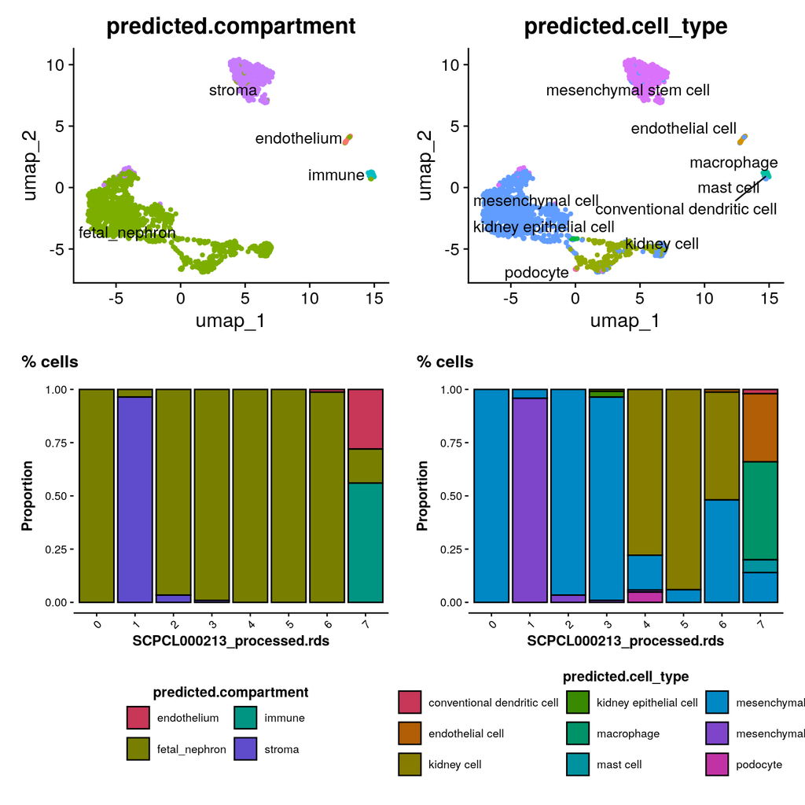

```r
d1 <- DimPlot(srat, reduction = "umap", dims = c(1,2), group.by = "predicted.compartment", label = TRUE, repel = TRUE) + NoLegend()
d2 <- DimPlot(srat, reduction = "umap", dims = c(1,2), group.by = "predicted.cell_type", label = TRUE, repel = TRUE) + NoLegend()

f1 <- SCpubr::do_BarPlot(sample = srat,
                         group.by = "predicted.compartment",
                         split.by = "seurat_clusters",
                         position = "fill",
                         font.size = 10,
                         legend.ncol = 3) +
                         ggtitle("% cells")+
                         xlab(file)

f2 <- SCpubr::do_BarPlot(sample = srat,
                         group.by = "predicted.cell_type",
                         split.by = "seurat_clusters",
                         position = "fill",
                         font.size = 10,
                         legend.ncol = 3) +
                         ggtitle("% cells")+
                         xlab(file)

(d1/f1) | (d2/f2)
```

Note:

For some reason, the “cap-mesenchyme cells” has been renamed in cellxgene in “mesenchymal cells”.

The cap mesenchyme is a cap of condensed metanephric mesenchyme, comprised of cells which epithelialize and sequentially form the pretubular aggregate (PA), renal vesicle (RV), C-, and S-shaped bodies, and finally the mature nephron. The CM contains nephron progenitor cells.

This can be confusing and we just need to pay attention that :

- the fetal nephron / mesenchymal cells are cap-mesenchyme cells. In our case, cap-mesenchyme contains blastema and primitive epitheliul cancer cells.
- the stroma / mesenchymal stem are likelly mesenchymal cancer or normal cells.

## References

- [1] https://www.ncbi.nlm.nih.gov/books/NBK373356/
- [2] https://www.ncbi.nlm.nih.gov/pmc/articles/PMC9915828/
- [3] https://www.science.org/doi/10.1126/science.aat5031
- [4] https://www.science.org/doi/10.1126/science.aba7721